# Variable Selection R Codes Examples

Hakan Gogtas

11/8/2020

##Best Subset Regression

Select the subset of predictors that do the best at meeting some well-defined objective criterion, such as having the largest R2 value or the smallest MSE, Mallow’s Cp or AIC.

```r
library(olsrr)
library(datasets)
exp <- lm(mpg ~ disp + hp, data = mtcars)
k <- ols_step_all_possible(exp)
k
```

|  | mindex | n | predictors | rsquare | adjr | predrsq | cp | aic | sbic | sbc | msep | fpe | apc | hsp |
| --- | --- | --- | --- | --- | --- | --- | --- | --- | --- | --- | --- | --- | --- | --- |
| 1 | 1 | 1 | disp | 0.7183433 | 0.7089548 | 0.6751205 | 4.443792 | 170.2094 | 79.34223 | 174.6066 | 338.3482 | 11.23270 | 0.3192109 | 0.3645502 |
| 2 | 2 | 1 | hp | 0.6024373 | 0.5891853 | 0.5096958 | 17.794906 | 181.2386 | 89.04015 | 185.6358 | 477.5836 | 15.85513 | 0.4505710 | 0.5145682 |
| 3 | 3 | 2 | disp hp | 0.7482402 | 0.7308774 | 0.6945438 | 3.000000 | 168.6186 | 78.40578 | 174.4815 | 313.2349 | 10.69210 | 0.3038481 | 0.3491298 |

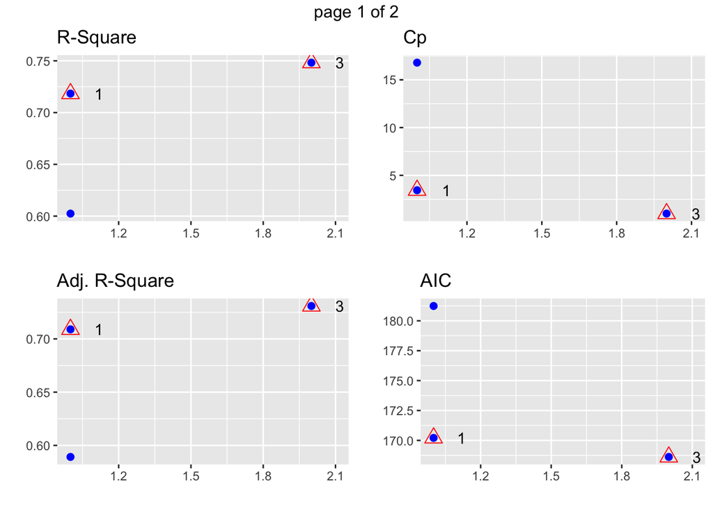

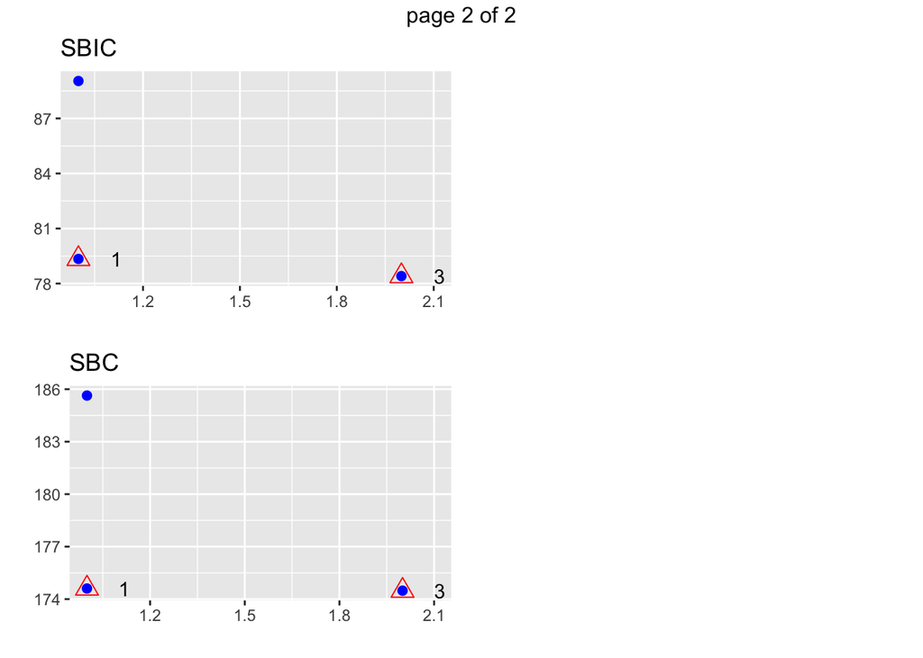

```r
plot(k)
```

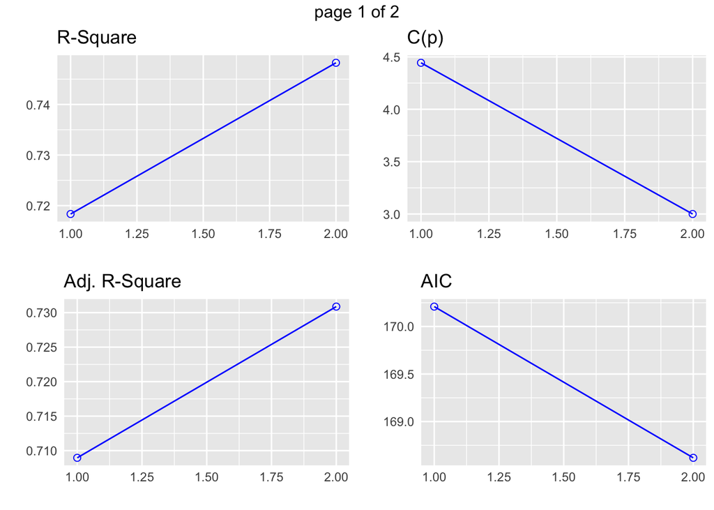

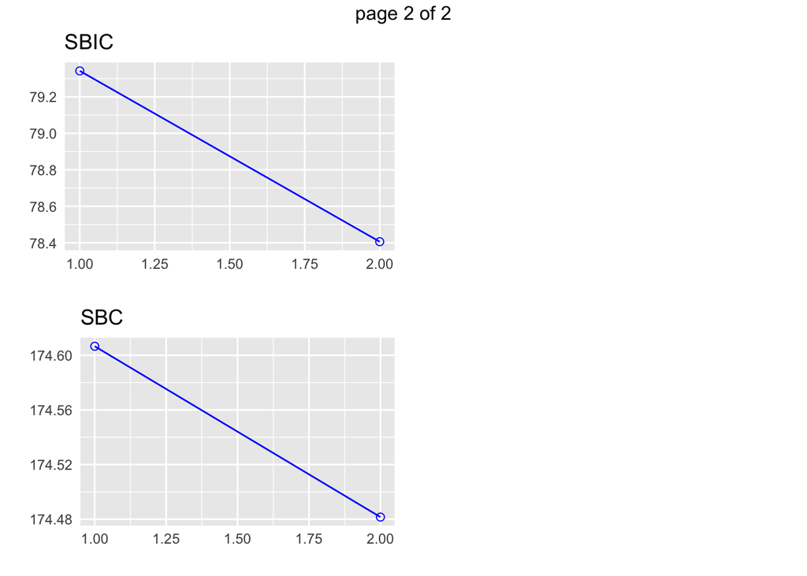

```r
k1<-ols_step_best_subset(exp)
plot(k1)
```

The plot method shows the panel of fit criteria for best subset regression methods.

##Stepwise Forward Regression

Build regression model from a set of candidate predictor variables by entering predictors based on p values, in a stepwise manner until there is no variable left to enter any more. The model should include all the candidate predictor variables. If details is set to TRUE, each step is displayed.

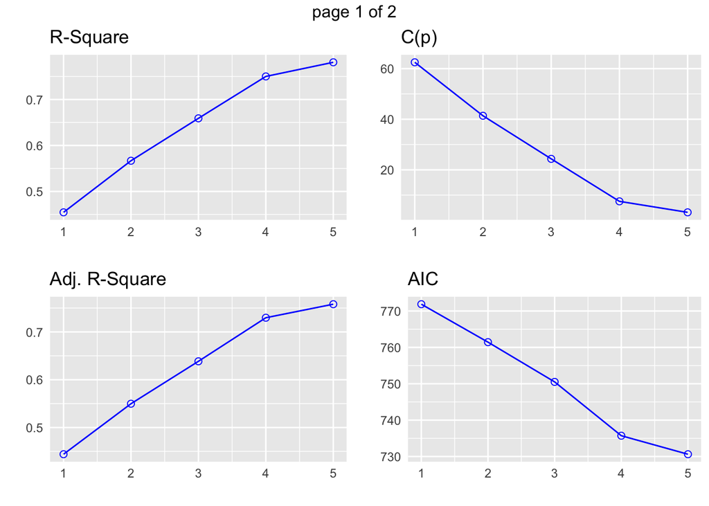

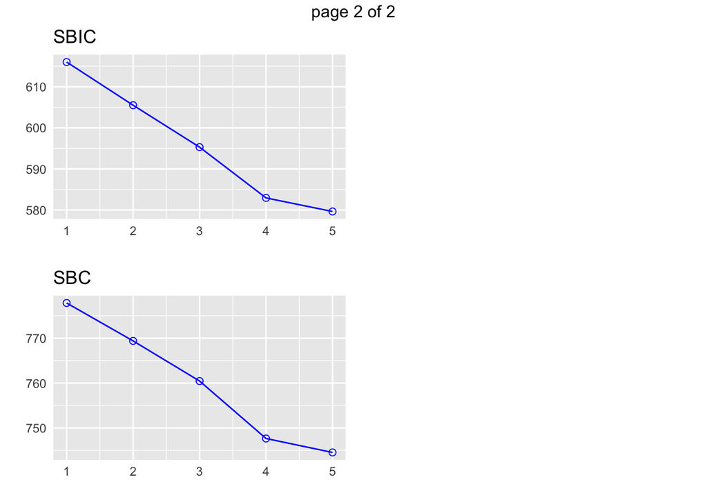

```r
# stepwise forward regression
exp2 <- lm(y ~ ., data = surgical)
k2<-ols_step_forward_p(exp2)
plot(k2)
```

```r
# stepwise forward regression
ols_step_forward_p(exp2, details = TRUE)
```

```
## Forward Selection Method
## ---------------------------
##
## Candidate Terms:
##
## 1. bcs
## 2. pindex
## 3. enzyme_test
## 4. liver_test
## 5. age
## 6. gender
## 7. alc_mod
## 8. alc_heavy
##
## We are selecting variables based on p value...
##
##
## Forward Selection: Step 1
##
## - liver_test
##
##                           Model Summary
## -----------------------------------------------------------------
## R                       0.674       RMSE                 296.299
## R-Squared               0.455       Coef. Var             42.202
## Adj. R-Squared          0.444       MSE                87793.232
## Pred R-Squared          0.386       MAE                  212.857
## -----------------------------------------------------------------
##  RMSE: Root Mean Square Error
##  MSE: Mean Square Error
##  MAE: Mean Absolute Error
##
##                                  ANOVA
## -----------------------------------------------------------------------
##                    Sum of
##                   Squares        DF    Mean Square      F         Sig.
## -----------------------------------------------------------------------
## Regression    3804272.477         1    3804272.477    43.332    0.0000
## Residual      4565248.060        52      87793.232
## Total         8369520.537        53
```

[output cut: 193 more lines]

```
## Residual      1833716.447        48      38202.426
## Total         8369520.537        53
## -----------------------------------------------------------------------
##
##                                       Parameter Estimates
## ------------------------------------------------------------------------------------------------
##       model         Beta    Std. Error    Std. Beta      t        Sig         lower       upper
## ------------------------------------------------------------------------------------------------
## (Intercept)    -1178.330       208.682                 -5.647    0.000    -1597.914    -758.746
##  liver_test       58.064        40.144        0.156     1.446    0.155      -22.652     138.779
##   alc_heavy      317.848        71.634        0.314     4.437    0.000      173.818     461.878
## enzyme_test        9.748         1.656        0.521     5.887    0.000        6.419      13.077
##      pindex        8.924         1.808        0.380     4.935    0.000        5.288      12.559
##         bcs       59.864        23.060        0.241     2.596    0.012       13.498     106.230
## ------------------------------------------------------------------------------------------------
```

```
##
##                               Selection Summary
## ------------------------------------------------------------------------------
##         Variable                     Adj.
## Step      Entered      R-Square    R-Square     C(p)        AIC         RMSE
## ------------------------------------------------------------------------------
##    1    liver_test       0.4545      0.4440    62.5119    771.8753    296.2992
##    2    alc_heavy        0.5667      0.5498    41.3681    761.4394    266.6484
##    3    enzyme_test      0.6590      0.6385    24.3379    750.5089    238.9145
##    4    pindex           0.7501      0.7297     7.5373    735.7146    206.5835
##    5    bcs              0.7809      0.7581     3.1925    730.6204    195.4544
## ------------------------------------------------------------------------------
```

##Stepwise Backward Regression

Build regression model from a set of candidate predictor variables by removing predictors based on p values, in a stepwise manner until there is no variable left to remove any more. The model should include all the candidate predictor variables. If details is set to TRUE, each step is displayed.

```r
# stepwise backward regression
k4<-ols_step_backward_p(exp2)
k4
```

```
##
##
##                            Elimination Summary
## --------------------------------------------------------------------------
##         Variable                  Adj.
## Step    Removed     R-Square    R-Square     C(p)       AIC         RMSE
## --------------------------------------------------------------------------
##    1    alc_mod       0.7818      0.7486    7.0141    734.4068    199.2637
##    2    gender        0.7814      0.7535    5.0870    732.4942    197.2921
##    3    age           0.7809      0.7581    3.1925    730.6204    195.4544
## --------------------------------------------------------------------------
```

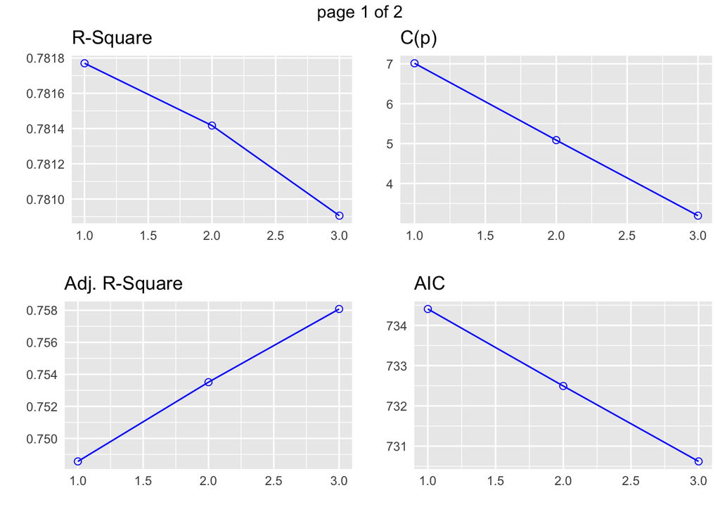

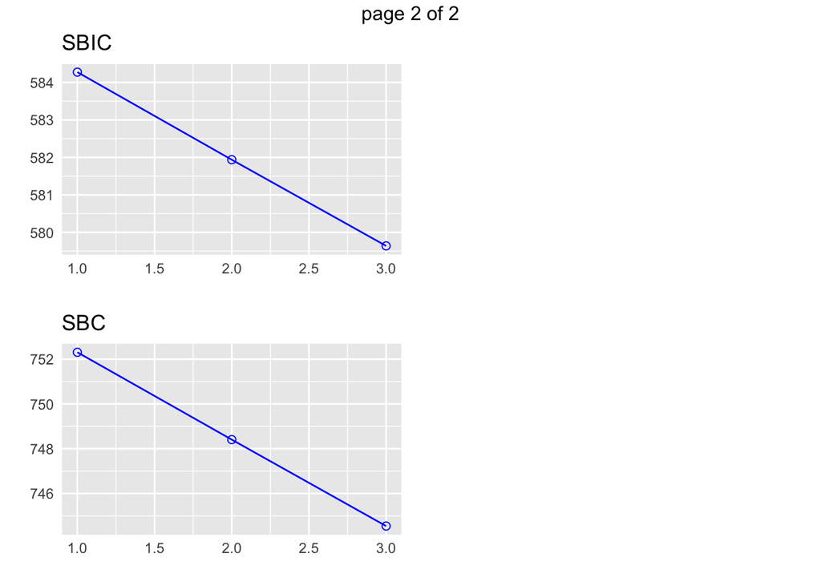

```r
plot(k4)
```

```r
#Detailed Output
# stepwise backward regression
ols_step_backward_p(exp2, details = TRUE)
```

```
## Backward Elimination Method
## ---------------------------
##
## Candidate Terms:
##
## 1 . bcs
## 2 . pindex
## 3 . enzyme_test
## 4 . liver_test
## 5 . age
## 6 . gender
## 7 . alc_mod
## 8 . alc_heavy
##
## We are eliminating variables based on p value...
##
## - alc_mod
##
## Backward Elimination: Step 1
##
##  Variable alc_mod Removed
##
##                           Model Summary
## -----------------------------------------------------------------
## R                       0.884       RMSE                 199.264
## R-Squared               0.782       Coef. Var             28.381
## Adj. R-Squared          0.749       MSE                39706.040
## Pred R-Squared          0.678       MAE                  137.053
## -----------------------------------------------------------------
##  RMSE: Root Mean Square Error
##  MSE: Mean Square Error
##  MAE: Mean Absolute Error
##
##                                  ANOVA
## -----------------------------------------------------------------------
##                    Sum of
##                   Squares        DF    Mean Square      F         Sig.
## -----------------------------------------------------------------------
## Regression    6543042.709         7     934720.387    23.541    0.0000
## Residual      1826477.828        46      39706.040
```

[output cut: 130 more lines]

```
## Residual      1833716.447        48      38202.426
## Total         8369520.537        53
## -----------------------------------------------------------------------
##
##                                       Parameter Estimates
## ------------------------------------------------------------------------------------------------
##       model         Beta    Std. Error    Std. Beta      t        Sig         lower       upper
## ------------------------------------------------------------------------------------------------
## (Intercept)    -1178.330       208.682                 -5.647    0.000    -1597.914    -758.746
##         bcs       59.864        23.060        0.241     2.596    0.012       13.498     106.230
##      pindex        8.924         1.808        0.380     4.935    0.000        5.288      12.559
## enzyme_test        9.748         1.656        0.521     5.887    0.000        6.419      13.077
##  liver_test       58.064        40.144        0.156     1.446    0.155      -22.652     138.779
##   alc_heavy      317.848        71.634        0.314     4.437    0.000      173.818     461.878
## ------------------------------------------------------------------------------------------------
```

```
##
##
##                            Elimination Summary
## --------------------------------------------------------------------------
##         Variable                  Adj.
## Step    Removed     R-Square    R-Square     C(p)       AIC         RMSE
## --------------------------------------------------------------------------
##    1    alc_mod       0.7818      0.7486    7.0141    734.4068    199.2637
##    2    gender        0.7814      0.7535    5.0870    732.4942    197.2921
##    3    age           0.7809      0.7581    3.1925    730.6204    195.4544
## --------------------------------------------------------------------------
```

##Stepwise Regression Build regression model from a set of candidate predictor variables by entering and removing predictors based on p values, in a stepwise manner until there is no variable left to enter or remove any more. The model should include all the candidate predictor variables. If details is set to TRUE, each step is displayed.

```r
# stepwise regression
ols_step_both_p(exp2,pent=0.1,prem=0.05,details=TRUE)
```

```
## Stepwise Selection Method
## ---------------------------
##
## Candidate Terms:
##
## 1. bcs
## 2. pindex
## 3. enzyme_test
## 4. liver_test
## 5. age
## 6. gender
## 7. alc_mod
## 8. alc_heavy
##
## We are selecting variables based on p value...
##
##
## Stepwise Selection: Step 1
##
## - liver_test added
##
##                           Model Summary
## -----------------------------------------------------------------
## R                       0.674       RMSE                 296.299
## R-Squared               0.455       Coef. Var             42.202
## Adj. R-Squared          0.444       MSE                87793.232
## Pred R-Squared          0.386       MAE                  212.857
## -----------------------------------------------------------------
##  RMSE: Root Mean Square Error
##  MSE: Mean Square Error
##  MAE: Mean Absolute Error
##
##                                  ANOVA
## -----------------------------------------------------------------------
##                    Sum of
##                   Squares        DF    Mean Square      F         Sig.
## -----------------------------------------------------------------------
## Regression    3804272.477         1    3804272.477    43.332    0.0000
## Residual      4565248.060        52      87793.232
## Total         8369520.537        53
```

[output cut: 356 more lines]

```
## Regression    6455884.265         4    1613971.066    41.327    0.0000
## Residual      1913636.272        49      39053.801
## Total         8369520.537        53
## -----------------------------------------------------------------------
##
##                                       Parameter Estimates
## ------------------------------------------------------------------------------------------------
##       model         Beta    Std. Error    Std. Beta      t        Sig         lower       upper
## ------------------------------------------------------------------------------------------------
## (Intercept)    -1334.424       180.589                 -7.389    0.000    -1697.332    -971.516
##   alc_heavy      312.777        72.341        0.309     4.324    0.000      167.402     458.152
## enzyme_test       11.243         1.308        0.601     8.596    0.000        8.614      13.871
##      pindex       10.131         1.622        0.431     6.246    0.000        6.871      13.390
##         bcs       81.439        17.781        0.329     4.580    0.000       45.706     117.171
## ------------------------------------------------------------------------------------------------
```

```
##
##                                 Stepwise Selection Summary
## ------------------------------------------------------------------------------------------
##                         Added/                   Adj.
## Step     Variable      Removed     R-Square    R-Square     C(p)        AIC         RMSE
## ------------------------------------------------------------------------------------------
##    1    liver_test     addition       0.455       0.444    62.5120    771.8753    296.2992
##    2     alc_heavy     addition       0.567       0.550    41.3680    761.4394    266.6484
##    3    enzyme_test    addition       0.659       0.639    24.3380    750.5089    238.9145
##    4      pindex       addition       0.750       0.730     7.5370    735.7146    206.5835
##    5        bcs        addition       0.781       0.758     3.1920    730.6204    195.4544
##    6    liver_test     removal        0.771       0.753     3.1620    730.9241    197.6203
## ------------------------------------------------------------------------------------------
```

```r
k5<-ols_step_both_p(exp2)
k5
```

```
##
##                                 Stepwise Selection Summary
## ------------------------------------------------------------------------------------------
##                         Added/                   Adj.
## Step     Variable      Removed     R-Square    R-Square     C(p)        AIC         RMSE
## ------------------------------------------------------------------------------------------
##    1    liver_test     addition       0.455       0.444    62.5120    771.8753    296.2992
##    2     alc_heavy     addition       0.567       0.550    41.3680    761.4394    266.6484
##    3    enzyme_test    addition       0.659       0.639    24.3380    750.5089    238.9145
##    4      pindex       addition       0.750       0.730     7.5370    735.7146    206.5835
##    5        bcs        addition       0.781       0.758     3.1920    730.6204    195.4544
## ------------------------------------------------------------------------------------------
```

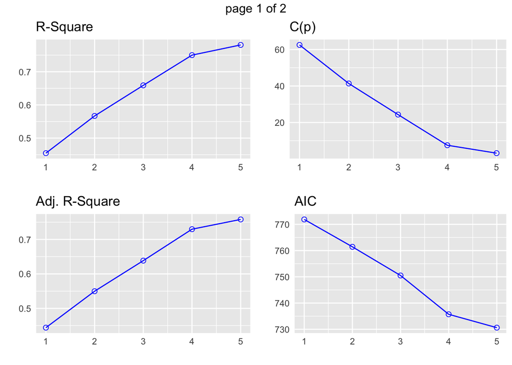

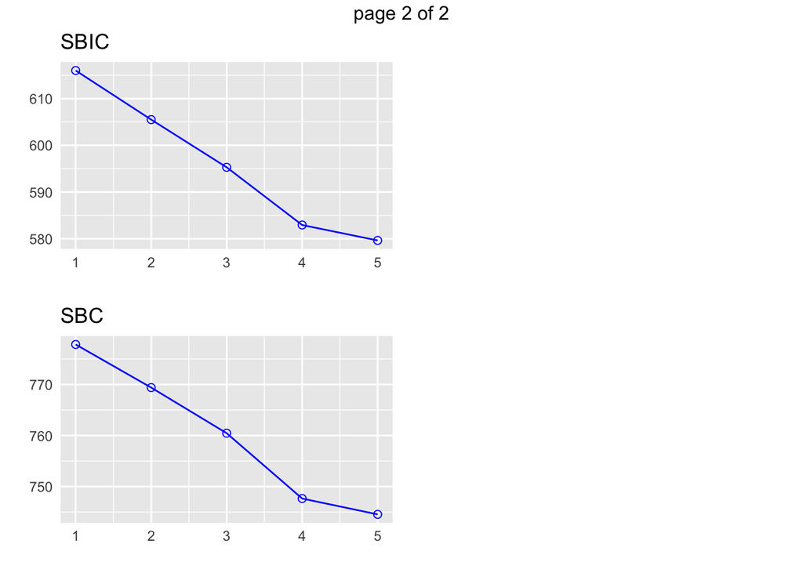

```r
plot(k5)
```

```r
#Detailed Output
ols_step_both_p(exp2, details = TRUE)
```

```
## Stepwise Selection Method
## ---------------------------
##
## Candidate Terms:
##
## 1. bcs
## 2. pindex
## 3. enzyme_test
## 4. liver_test
## 5. age
## 6. gender
## 7. alc_mod
## 8. alc_heavy
##
## We are selecting variables based on p value...
##
##
## Stepwise Selection: Step 1
##
## - liver_test added
##
##                           Model Summary
## -----------------------------------------------------------------
## R                       0.674       RMSE                 296.299
## R-Squared               0.455       Coef. Var             42.202
## Adj. R-Squared          0.444       MSE                87793.232
## Pred R-Squared          0.386       MAE                  212.857
## -----------------------------------------------------------------
##  RMSE: Root Mean Square Error
##  MSE: Mean Square Error
##  MAE: Mean Absolute Error
##
##                                  ANOVA
## -----------------------------------------------------------------------
##                    Sum of
##                   Squares        DF    Mean Square      F         Sig.
## -----------------------------------------------------------------------
## Regression    3804272.477         1    3804272.477    43.332    0.0000
## Residual      4565248.060        52      87793.232
## Total         8369520.537        53
```

[output cut: 319 more lines]

```
## Residual      1833716.447        48      38202.426
## Total         8369520.537        53
## -----------------------------------------------------------------------
##
##                                       Parameter Estimates
## ------------------------------------------------------------------------------------------------
##       model         Beta    Std. Error    Std. Beta      t        Sig         lower       upper
## ------------------------------------------------------------------------------------------------
## (Intercept)    -1178.330       208.682                 -5.647    0.000    -1597.914    -758.746
##  liver_test       58.064        40.144        0.156     1.446    0.155      -22.652     138.779
##   alc_heavy      317.848        71.634        0.314     4.437    0.000      173.818     461.878
## enzyme_test        9.748         1.656        0.521     5.887    0.000        6.419      13.077
##      pindex        8.924         1.808        0.380     4.935    0.000        5.288      12.559
##         bcs       59.864        23.060        0.241     2.596    0.012       13.498     106.230
## ------------------------------------------------------------------------------------------------
```

```
##
##                                 Stepwise Selection Summary
## ------------------------------------------------------------------------------------------
##                         Added/                   Adj.
## Step     Variable      Removed     R-Square    R-Square     C(p)        AIC         RMSE
## ------------------------------------------------------------------------------------------
##    1    liver_test     addition       0.455       0.444    62.5120    771.8753    296.2992
##    2     alc_heavy     addition       0.567       0.550    41.3680    761.4394    266.6484
##    3    enzyme_test    addition       0.659       0.639    24.3380    750.5089    238.9145
##    4      pindex       addition       0.750       0.730     7.5370    735.7146    206.5835
##    5        bcs        addition       0.781       0.758     3.1920    730.6204    195.4544
## ------------------------------------------------------------------------------------------
```

##Stepwise AIC Forward Regression Build regression model from a set of candidate predictor variables by entering predictors based on Akaike Information Criteria, in a stepwise manner until there is no variable left to enter any more. The model should include all the candidate predictor variables. If details is set to TRUE, each step is displayed.

```r
# stepwise aic forward regression
k6<-ols_step_forward_aic(exp2)
k6
```

```
##
##                              Selection Summary
## ----------------------------------------------------------------------------
## Variable         AIC        Sum Sq           RSS         R-Sq      Adj. R-Sq
## ----------------------------------------------------------------------------
## liver_test     771.875    3804272.477    4565248.060    0.45454      0.44405
## alc_heavy      761.439    4743349.776    3626170.761    0.56674      0.54975
## enzyme_test    750.509    5515514.136    2854006.401    0.65900      0.63854
## pindex         735.715    6278360.060    2091160.477    0.75015      0.72975
## bcs            730.620    6535804.090    1833716.447    0.78091      0.75808
## ----------------------------------------------------------------------------
```

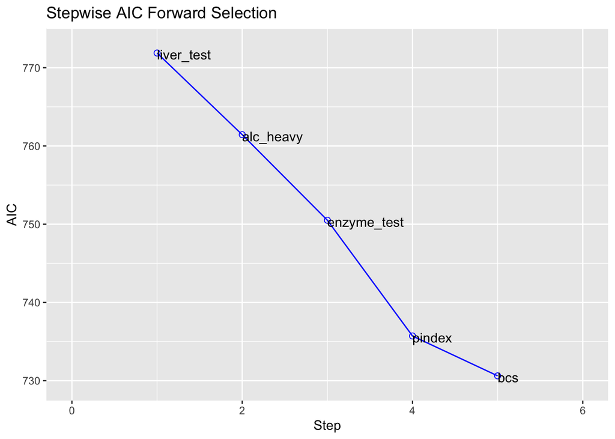

```r
plot(k6)
```

```r
ols_step_forward_aic(exp2, details = TRUE)
```

```
## Forward Selection Method
## ------------------------
##
## Candidate Terms:
##
## 1 . bcs
## 2 . pindex
## 3 . enzyme_test
## 4 . liver_test
## 5 . age
## 6 . gender
## 7 . alc_mod
## 8 . alc_heavy
##
##  Step 0: AIC = 802.606
##  y ~ 1
##
## --------------------------------------------------------------------------------
## Variable       DF      AIC        Sum Sq           RSS        R-Sq     Adj. R-Sq
## --------------------------------------------------------------------------------
## liver_test      1    771.875    3804272.477    4565248.060    0.455        0.444
## enzyme_test     1    782.629    2798309.881    5571210.656    0.334        0.322
## pindex          1    794.100    1479766.754    6889753.784    0.177        0.161
## alc_heavy       1    794.301    1454057.255    6915463.282    0.174        0.158
## bcs             1    797.697    1005151.658    7364368.879    0.120        0.103
## alc_mod         1    802.828     271062.330    8098458.207    0.032        0.014
## gender          1    802.956     251808.570    8117711.967    0.030        0.011
## age             1    803.834     118862.559    8250657.978    0.014       -0.005
## --------------------------------------------------------------------------------
##
##
## - liver_test
##
##
##  Step 1 : AIC = 771.8753
##  y ~ liver_test
##
## -------------------------------------------------------------------------------
## Variable       DF      AIC        Sum Sq          RSS        R-Sq     Adj. R-Sq
## -------------------------------------------------------------------------------
```

[output cut: 103 more lines]

```
## Residual      1833716.447        48      38202.426
## Total         8369520.537        53
## -----------------------------------------------------------------------
##
##                                       Parameter Estimates
## ------------------------------------------------------------------------------------------------
##       model         Beta    Std. Error    Std. Beta      t        Sig         lower       upper
## ------------------------------------------------------------------------------------------------
## (Intercept)    -1178.330       208.682                 -5.647    0.000    -1597.914    -758.746
##  liver_test       58.064        40.144        0.156     1.446    0.155      -22.652     138.779
##   alc_heavy      317.848        71.634        0.314     4.437    0.000      173.818     461.878
## enzyme_test        9.748         1.656        0.521     5.887    0.000        6.419      13.077
##      pindex        8.924         1.808        0.380     4.935    0.000        5.288      12.559
##         bcs       59.864        23.060        0.241     2.596    0.012       13.498     106.230
## ------------------------------------------------------------------------------------------------
```

```
##
##                              Selection Summary
## ----------------------------------------------------------------------------
## Variable         AIC        Sum Sq           RSS         R-Sq      Adj. R-Sq
## ----------------------------------------------------------------------------
## liver_test     771.875    3804272.477    4565248.060    0.45454      0.44405
## alc_heavy      761.439    4743349.776    3626170.761    0.56674      0.54975
## enzyme_test    750.509    5515514.136    2854006.401    0.65900      0.63854
## pindex         735.715    6278360.060    2091160.477    0.75015      0.72975
## bcs            730.620    6535804.090    1833716.447    0.78091      0.75808
## ----------------------------------------------------------------------------
```

## Stepwise AIC Backward Regression

Build regression model from a set of candidate predictor variables by removing predictors based on Akaike Information Criteria, in a stepwise manner until there is no variable left to remove any more. The model should include all the candidate predictor variables. If details is set to TRUE, each step is displayed.

```r
k7 <- ols_step_backward_aic(exp2)
k7
```

```
##
##
##                         Backward Elimination Summary
## ---------------------------------------------------------------------------
## Variable        AIC          RSS          Sum Sq        R-Sq      Adj. R-Sq
## ---------------------------------------------------------------------------
## Full Model    736.390    1825905.713    6543614.824    0.78184      0.74305
## alc_mod       734.407    1826477.828    6543042.709    0.78177      0.74856
## gender        732.494    1829435.617    6540084.920    0.78142      0.75351
## age           730.620    1833716.447    6535804.090    0.78091      0.75808
## ---------------------------------------------------------------------------
```

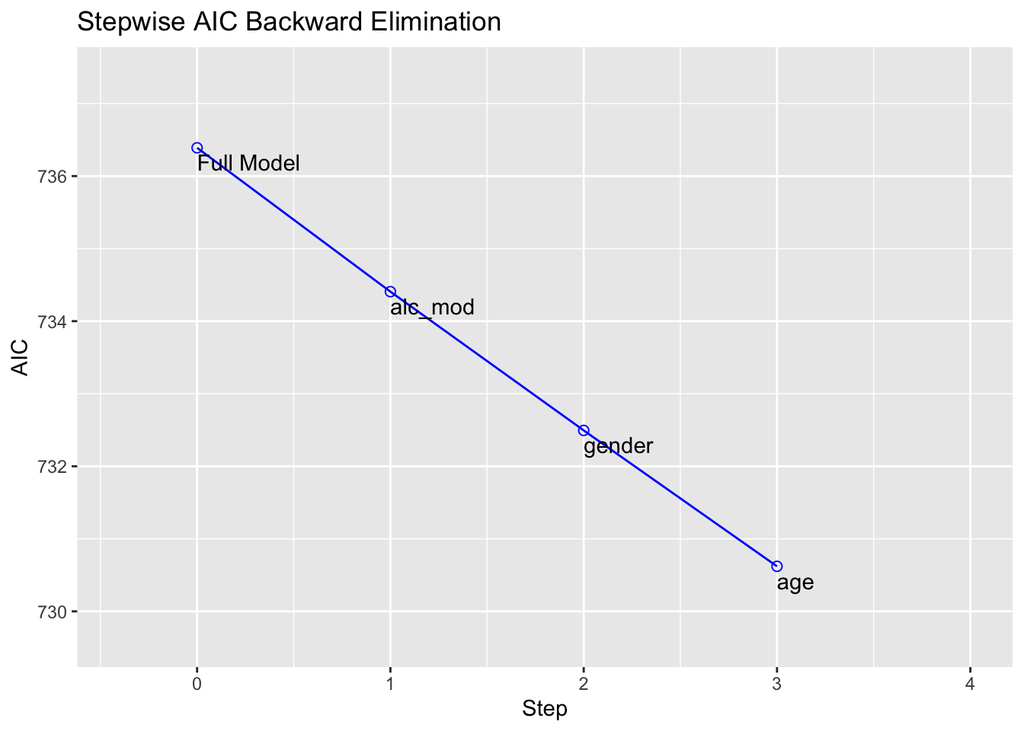

```r
plot(k7)
```

```r
ols_step_backward_aic(exp2, details = TRUE)
```

```
## Backward Elimination Method
## ---------------------------
##
## Candidate Terms:
##
## 1 . bcs
## 2 . pindex
## 3 . enzyme_test
## 4 . liver_test
## 5 . age
## 6 . gender
## 7 . alc_mod
## 8 . alc_heavy
##
##  Step 0: AIC = 736.3899
##  y ~ bcs + pindex + enzyme_test + liver_test + age + gender + alc_mod + alc_heavy
##
## --------------------------------------------------------------------------------
## Variable       DF      AIC        Sum Sq           RSS        R-Sq     Adj. R-Sq
## --------------------------------------------------------------------------------
## alc_mod        1     734.407        572.115    1826477.828    0.782        0.749
## gender         1     734.478       2990.338    1828896.051    0.781        0.748
## age            1     734.544       5231.108    1831136.821    0.781        0.748
## liver_test     1     735.878      51016.156    1876921.869    0.776        0.742
## bcs            1     741.677     263780.393    2089686.106    0.750        0.712
## alc_heavy      1     749.210     576636.222    2402541.935    0.713        0.669
## pindex         1     756.624     930187.311    2756093.024    0.671        0.621
## enzyme_test    1     763.557    1307756.930    3133662.644    0.626        0.569
## --------------------------------------------------------------------------------
##
##
## Variables Removed:
##
## - alc_mod
##
##
##   Step 1 : AIC = 734.4068
##  y ~ bcs + pindex + enzyme_test + liver_test + age + gender + alc_heavy
##
## --------------------------------------------------------------------------------
```

[output cut: 74 more lines]

```
## Residual      1833716.447        48      38202.426
## Total         8369520.537        53
## -----------------------------------------------------------------------
##
##                                       Parameter Estimates
## ------------------------------------------------------------------------------------------------
##       model         Beta    Std. Error    Std. Beta      t        Sig         lower       upper
## ------------------------------------------------------------------------------------------------
## (Intercept)    -1178.330       208.682                 -5.647    0.000    -1597.914    -758.746
##         bcs       59.864        23.060        0.241     2.596    0.012       13.498     106.230
##      pindex        8.924         1.808        0.380     4.935    0.000        5.288      12.559
## enzyme_test        9.748         1.656        0.521     5.887    0.000        6.419      13.077
##  liver_test       58.064        40.144        0.156     1.446    0.155      -22.652     138.779
##   alc_heavy      317.848        71.634        0.314     4.437    0.000      173.818     461.878
## ------------------------------------------------------------------------------------------------
```

```
##
##
##                         Backward Elimination Summary
## ---------------------------------------------------------------------------
## Variable        AIC          RSS          Sum Sq        R-Sq      Adj. R-Sq
## ---------------------------------------------------------------------------
## Full Model    736.390    1825905.713    6543614.824    0.78184      0.74305
## alc_mod       734.407    1826477.828    6543042.709    0.78177      0.74856
## gender        732.494    1829435.617    6540084.920    0.78142      0.75351
## age           730.620    1833716.447    6535804.090    0.78091      0.75808
## ---------------------------------------------------------------------------
```

## Stepwise AIC Regression

Build regression model from a set of candidate predictor variables by entering and removing predictors based on Akaike Information Criteria, in a stepwise manner until there is no variable left to enter or remove any more. The model should include all the candidate predictor variables. If details is set to TRUE, each step is displayed.

```r
k8<-ols_step_both_aic(exp2)
k8
```

```
##
##
##                                      Stepwise Summary
## ----------------------------------------------------------------------------------------
## Variable        Method       AIC          RSS          Sum Sq        R-Sq      Adj. R-Sq
## ----------------------------------------------------------------------------------------
## liver_test     addition    771.875    4565248.060    3804272.477    0.45454      0.44405
## alc_heavy      addition    761.439    3626170.761    4743349.776    0.56674      0.54975
## enzyme_test    addition    750.509    2854006.401    5515514.136    0.65900      0.63854
## pindex         addition    735.715    2091160.477    6278360.060    0.75015      0.72975
## bcs            addition    730.620    1833716.447    6535804.090    0.78091      0.75808
## ----------------------------------------------------------------------------------------
```

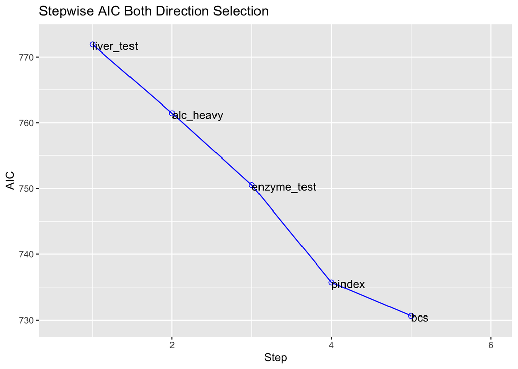

```r
plot(k8)
```

```r
ols_step_both_aic(exp2, details = TRUE)
```

```
## Stepwise Selection Method
## -------------------------
##
## Candidate Terms:
##
## 1 . bcs
## 2 . pindex
## 3 . enzyme_test
## 4 . liver_test
## 5 . age
## 6 . gender
## 7 . alc_mod
## 8 . alc_heavy
##
##  Step 0: AIC = 802.606
##  y ~ 1
##
##
## Variables Entered/Removed:
##
##                                Enter New Variables
## --------------------------------------------------------------------------------
## Variable       DF      AIC        Sum Sq           RSS        R-Sq     Adj. R-Sq
## --------------------------------------------------------------------------------
## liver_test      1    771.875    3804272.477    4565248.060    0.455        0.444
## enzyme_test     1    782.629    2798309.881    5571210.656    0.334        0.322
## pindex          1    794.100    1479766.754    6889753.784    0.177        0.161
## alc_heavy       1    794.301    1454057.255    6915463.282    0.174        0.158
## bcs             1    797.697    1005151.658    7364368.879    0.120        0.103
## alc_mod         1    802.828     271062.330    8098458.207    0.032        0.014
## gender          1    802.956     251808.570    8117711.967    0.030        0.011
## age             1    803.834     118862.559    8250657.978    0.014       -0.005
## --------------------------------------------------------------------------------
##
## - liver_test added
##
##
##  Step 1 : AIC = 771.8753
##  y ~ liver_test
##
```

[output cut: 140 more lines]

```
## Residual      1833716.447        48      38202.426
## Total         8369520.537        53
## -----------------------------------------------------------------------
##
##                                       Parameter Estimates
## ------------------------------------------------------------------------------------------------
##       model         Beta    Std. Error    Std. Beta      t        Sig         lower       upper
## ------------------------------------------------------------------------------------------------
## (Intercept)    -1178.330       208.682                 -5.647    0.000    -1597.914    -758.746
##  liver_test       58.064        40.144        0.156     1.446    0.155      -22.652     138.779
##   alc_heavy      317.848        71.634        0.314     4.437    0.000      173.818     461.878
## enzyme_test        9.748         1.656        0.521     5.887    0.000        6.419      13.077
##      pindex        8.924         1.808        0.380     4.935    0.000        5.288      12.559
##         bcs       59.864        23.060        0.241     2.596    0.012       13.498     106.230
## ------------------------------------------------------------------------------------------------
```

```
##
##
##                                      Stepwise Summary
## ----------------------------------------------------------------------------------------
## Variable        Method       AIC          RSS          Sum Sq        R-Sq      Adj. R-Sq
## ----------------------------------------------------------------------------------------
## liver_test     addition    771.875    4565248.060    3804272.477    0.45454      0.44405
## alc_heavy      addition    761.439    3626170.761    4743349.776    0.56674      0.54975
## enzyme_test    addition    750.509    2854006.401    5515514.136    0.65900      0.63854
## pindex         addition    735.715    2091160.477    6278360.060    0.75015      0.72975
## bcs            addition    730.620    1833716.447    6535804.090    0.78091      0.75808
## ----------------------------------------------------------------------------------------
```

```r
state.x77[1:10,]
```

```
##             Population Income Illiteracy Life Exp Murder HS Grad Frost   Area
## Alabama           3615   3624        2.1    69.05   15.1    41.3    20  50708
## Alaska             365   6315        1.5    69.31   11.3    66.7   152 566432
## Arizona           2212   4530        1.8    70.55    7.8    58.1    15 113417
## Arkansas          2110   3378        1.9    70.66   10.1    39.9    65  51945
## California       21198   5114        1.1    71.71   10.3    62.6    20 156361
## Colorado          2541   4884        0.7    72.06    6.8    63.9   166 103766
## Connecticut       3100   5348        1.1    72.48    3.1    56.0   139   4862
## Delaware           579   4809        0.9    70.06    6.2    54.6   103   1982
## Florida           8277   4815        1.3    70.66   10.7    52.6    11  54090
## Georgia           4931   4091        2.0    68.54   13.9    40.6    60  58073
```

```r
state<-data.frame(state.x77)
require(leaps)
b<-regsubsets(Life.Exp~.,data=state)
rs<-summary(b)
rs$which
```

```
##   (Intercept) Population Income Illiteracy Murder HS.Grad Frost  Area
## 1        TRUE      FALSE  FALSE      FALSE   TRUE   FALSE FALSE FALSE
## 2        TRUE      FALSE  FALSE      FALSE   TRUE    TRUE FALSE FALSE
## 3        TRUE      FALSE  FALSE      FALSE   TRUE    TRUE  TRUE FALSE
## 4        TRUE       TRUE  FALSE      FALSE   TRUE    TRUE  TRUE FALSE
## 5        TRUE       TRUE   TRUE      FALSE   TRUE    TRUE  TRUE FALSE
## 6        TRUE       TRUE   TRUE       TRUE   TRUE    TRUE  TRUE FALSE
## 7        TRUE       TRUE   TRUE       TRUE   TRUE    TRUE  TRUE  TRUE
```

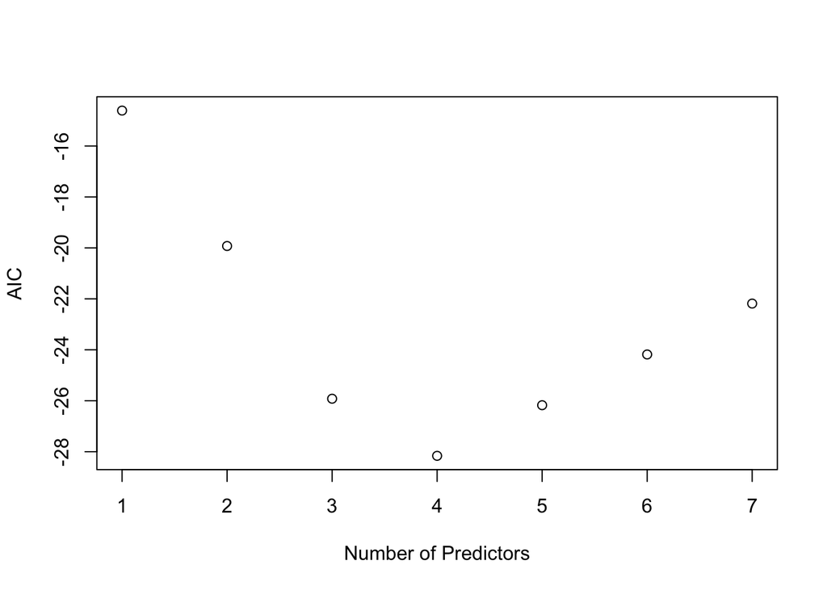

```r
AIC<-50*log(rs$rss/50)+(2:8)*2
plot(AIC~I(1:7),ylab="AIC",xlab="Number of Predictors")
```

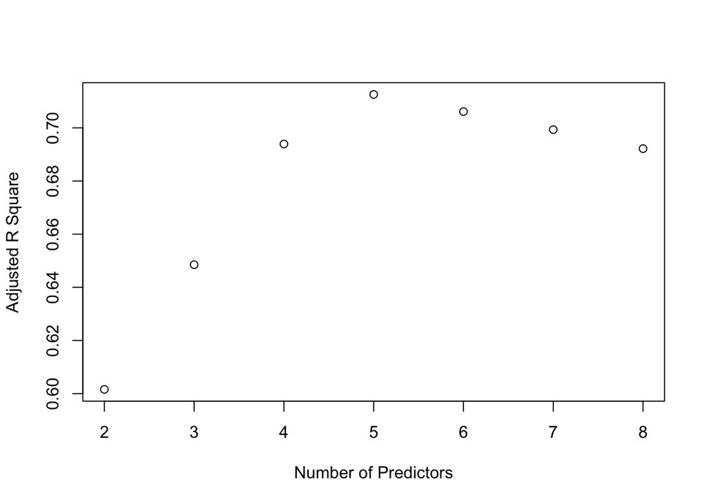

```r
plot(2:8,rs$adjr2,xlab="Number of Predictors",ylab="Adjusted R Square")
```

```r
which.max(rs$adjr2)
```

```
## [1] 4
```

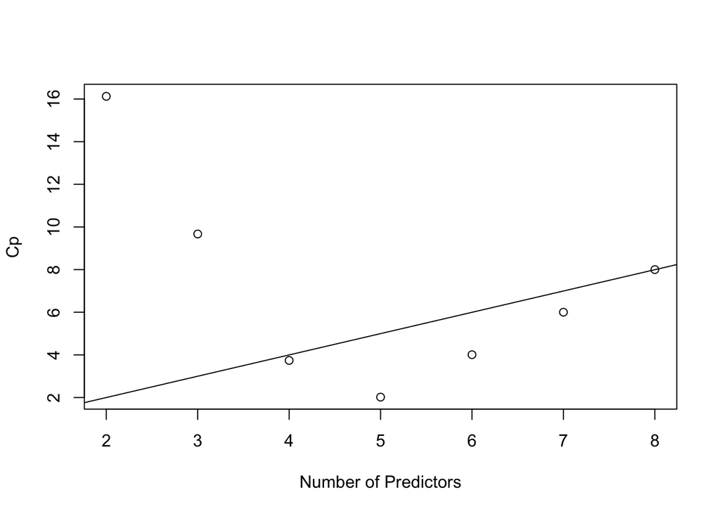

```r
plot(2:8,rs$cp,xlab="Number of Predictors",ylab="Cp")
abline(0,1)
```

The competition is between the four-parameter, three-predictor, model including frost, high school graduation and murder and the model also including population. Both models are on or below the Cp = p line, indicating good fits. The choice is between the smaller model and the larger model, which fits a little better. Some even larger models fit in the sense that they are on or below the Cp = p line, but we would not opt for these in the presence of smaller models that fit.

```r
f<-lm(Life.Exp~.,data=state)
step(f)
```

```
## Start:  AIC=-22.18
## Life.Exp ~ Population + Income + Illiteracy + Murder + HS.Grad +
##     Frost + Area
##
##              Df Sum of Sq    RSS     AIC
## - Area        1    0.0011 23.298 -24.182
## - Income      1    0.0044 23.302 -24.175
## - Illiteracy  1    0.0047 23.302 -24.174
## <none>                    23.297 -22.185
## - Population  1    1.7472 25.044 -20.569
## - Frost       1    1.8466 25.144 -20.371
## - HS.Grad     1    2.4413 25.738 -19.202
## - Murder      1   23.1411 46.438  10.305
##
## Step:  AIC=-24.18
## Life.Exp ~ Population + Income + Illiteracy + Murder + HS.Grad +
##     Frost
##
##              Df Sum of Sq    RSS     AIC
## - Illiteracy  1    0.0038 23.302 -26.174
## - Income      1    0.0059 23.304 -26.170
## <none>                    23.298 -24.182
## - Population  1    1.7599 25.058 -22.541
## - Frost       1    2.0488 25.347 -21.968
## - HS.Grad     1    2.9804 26.279 -20.163
## - Murder      1   26.2721 49.570  11.569
##
## Step:  AIC=-26.17
## Life.Exp ~ Population + Income + Murder + HS.Grad + Frost
##
##              Df Sum of Sq    RSS     AIC
## - Income      1     0.006 23.308 -28.161
## <none>                    23.302 -26.174
## - Population  1     1.887 25.189 -24.280
## - Frost       1     3.037 26.339 -22.048
## - HS.Grad     1     3.495 26.797 -21.187
## - Murder      1    34.739 58.041  17.456
##
## Step:  AIC=-28.16
## Life.Exp ~ Population + Murder + HS.Grad + Frost
##
##              Df Sum of Sq    RSS     AIC
## <none>                    23.308 -28.161
## - Population  1     2.064 25.372 -25.920
## - Frost       1     3.122 26.430 -23.877
## - HS.Grad     1     5.112 28.420 -20.246
## - Murder      1    34.816 58.124  15.528
```

```
##
## Call:
## lm(formula = Life.Exp ~ Population + Murder + HS.Grad + Frost,
##     data = state)
##
## Coefficients:
## (Intercept)   Population       Murder      HS.Grad        Frost
##   7.103e+01    5.014e-05   -3.001e-01    4.658e-02   -5.943e-03
```

```r
f1<-update(f,.~.- Area)
summary(f1)
```

```
##
## Call:
## lm(formula = Life.Exp ~ Population + Income + Illiteracy + Murder +
##     HS.Grad + Frost, data = state)
##
## Residuals:
##      Min       1Q   Median       3Q      Max
## -1.49047 -0.52533 -0.02546  0.57160  1.50374
##
## Coefficients:
##               Estimate Std. Error t value Pr(>|t|)
## (Intercept)  7.099e+01  1.387e+00  51.165  < 2e-16 ***
## Population   5.188e-05  2.879e-05   1.802   0.0785 .
## Income      -2.444e-05  2.343e-04  -0.104   0.9174
## Illiteracy   2.846e-02  3.416e-01   0.083   0.9340
## Murder      -3.018e-01  4.334e-02  -6.963 1.45e-08 ***
## HS.Grad      4.847e-02  2.067e-02   2.345   0.0237 *
## Frost       -5.776e-03  2.970e-03  -1.945   0.0584 .
## ---
## Signif. codes:  0 '***' 0.001 '**' 0.01 '*' 0.05 '.' 0.1 ' ' 1
##
## Residual standard error: 0.7361 on 43 degrees of freedom
## Multiple R-squared:  0.7361, Adjusted R-squared:  0.6993
## F-statistic: 19.99 on 6 and 43 DF,  p-value: 5.362e-11
```

```r
f1<-update(f1,.~.- Illiteracy )
f1<-update(f1,.~.- Income)
```